# Red Wine Quality Exploration by Layali R.

### Sulphates and chlorides

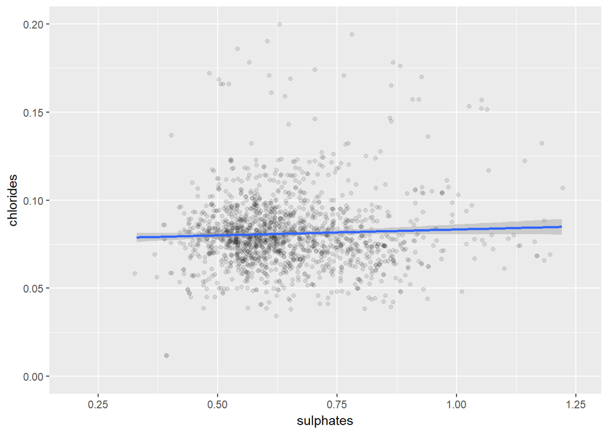

```
##
##  Pearson's product-moment correlation
##
## data:  df$sulphates and df$chlorides
## t = 15.978, df = 1597, p-value < 2.2e-16
## alternative hypothesis: true correlation is not equal to 0
## 95 percent confidence interval:
##  0.3282127 0.4127694
## sample estimates:
##       cor
## 0.3712605
```

> There is a weak relationship between sulphates and chlorides with R = 0.37. I’m not a chemist but I looked it up and there is no chemical relationship between the two compounds so I think that this relationship is fake.

### Free, bound, total sulfur dioxide and sulphates

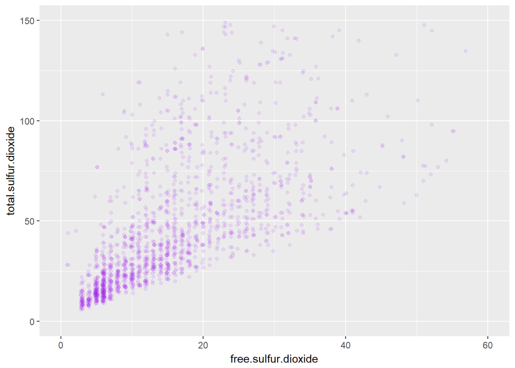

> Recall that total sulfur dioxide is a superset of free.sulfur.dioxide and bound sulfur dioxide (per the dataset description). The plot confirms this because we don’t see a point where free sulfur dioxide is larger than the total. It seems like bound sulfur dioxide composed most of the total sulfur dioxide because the range of sulphates is small.

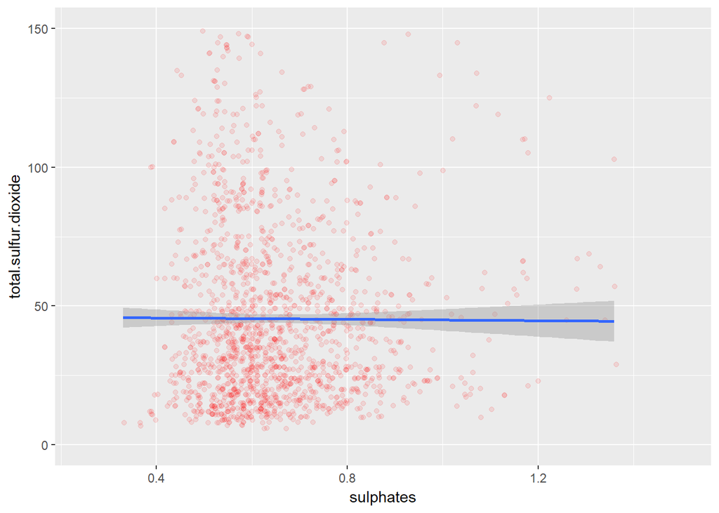

> The plot also shows that the majority of observations have small sulphates value mainly between 0.4 to 0.8. It also shows a number of observations with high total.sulfur.dioxide value and still very low sulphate value. Therefore, there is no obvious linear relationship between the two variables although their description implies a relationship. I plot the smooth line and it confirms my expectations.

# Bivariate Analysis

> Talk about some of the relationships you observed in this part of the  
> investigation. How did the feature(s) of interest vary with other features in dataset? I found a positive relatively good relationship between wine quality and alcohol, and a negative weak relationship with volatile acidity. Wine quality depends on other factors but the main components seem to be alcohol and volatile acidity.

> Did you observe any interesting relationships between the other features (not the main feature(s) of interest)? (1) There is a relatively strong negative relationship between fixed acidity and pH. Also a weaker relationship exists between citric acidity and pH. As for volatile acidity there is a weak negative relationship that I suspect to be fake due to some related documents I read about how the acidity density is measured in win. (2) Analysis reveals good negative relationship between density and alcohol. However, the relationship with residual sugar seems to be weaker and positive. Rather, I found a stronger positive relationship between density and total acidity (fixed acidity + citric acidity). (3) Dataset description claims a relationship between sulphates and sulfur dioxides but I couldn’t find any worthy relationship between the two variables. (4) Total sulphates consists of free sulphates and bound sulphates. I found that total sulphates are superset of free sulphates and it looks like the majority of sulphates is of type bound.

> What was the strongest relationship you found? The relationship between pH and total acidity has the strongest negative R value of 0.69.

# Multivariate Analysis

> Talk about some of the relationships you observed in this part of the  
> Contrary to what the dataset description says, the relationship between residual sugar and density is weaker than density relationship with total acidity (R of 0.66). However, alcohol which is also mentioned in the description has a good R of -0.50.

> Were there any interesting or surprising interactions between features? The fixed acidity and citric acidity have an interesting strong relationship with pH.

# Final Plots and Summary

### Plot One

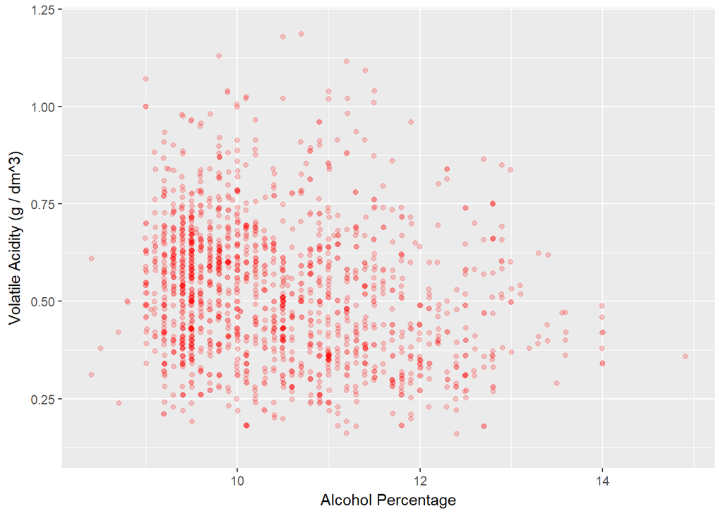

[output not shown]

### Plot Two

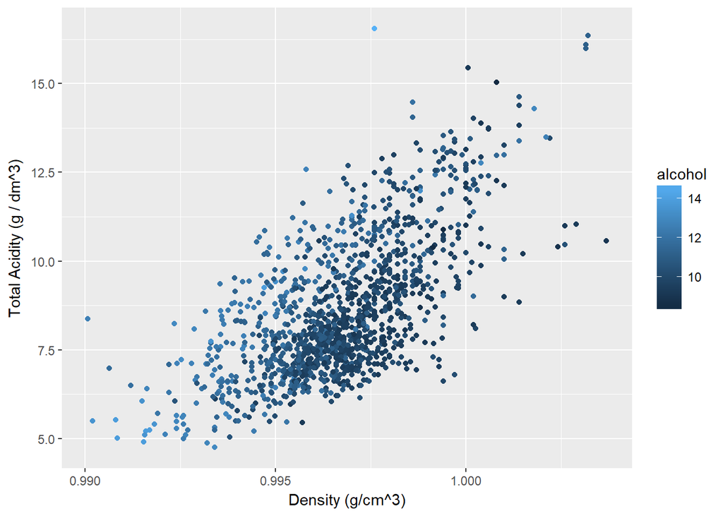

[output not shown]

### Description Two

> This plot shows the nice positive relationship between density and total acidity and a negative one with alcohol. Residual sugar doesn’t correlate much with density as the dataset description says. It is rather alcohol and total acidity that seem to be the major contributers. I think more statistical analysis are needed to determine if the relationship between density and total acidity is real or an artifact of other relationships, but I cannot see that by using my current tools.

### Plot Three

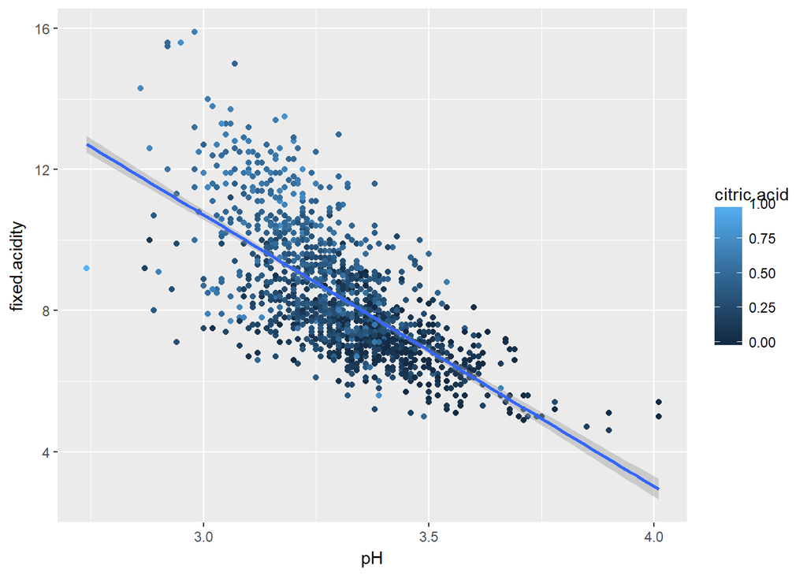

### Description Three

> In high concentration the fixed acids can give the wine tartaric taste. There is strong negative relationship between pH and fixed acidity. The pearson correlation coeficient is -0.68. Fixed acidity is very important in wine industry, it gives each wine its own characteristic. Fixed and citric acids are the two factors that contribute to pH in this dataset.

## Reflection

> This EDA was interesting, I proved a few relationships, debunked some and found new ones. I enjoyed learning about red wine components. I wish there were more observations, especially of low and high qualities so some relationships would become clearer. It is well polished dataset with all unique observations and no missing values. I also felt that I need to develop stronger chemistry background to better understand the relationships between the different compounds. I wasn’t suprised to find that alcohol is a major contributer to good wine, but volatile acidity was a little surprising to stand out in a negative relationship, I expected total acidity to be a stronger contributer.